# Project Thera Bank

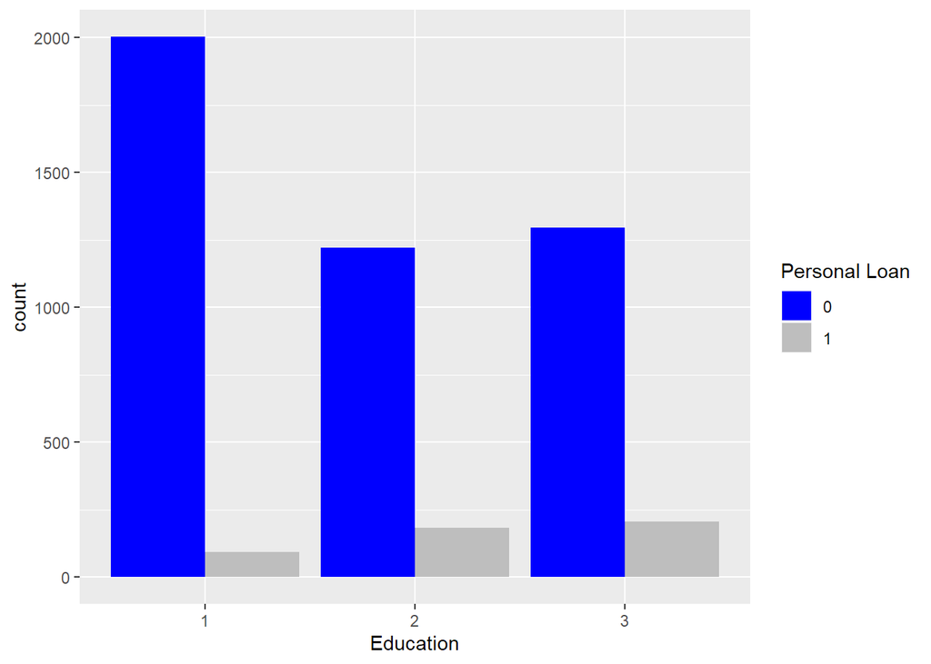

```r
# Across personal loans, lower average credit card spending, income and mortgage are less likely to take a personal loan. There are also some outliers who have high mortgages and average credit card spending who did not take up a personal loan.

ggplot(theradata, aes(Education, fill= Personal.Loan)) +
    geom_bar(stat = "count", position = "dodge") +
    scale_fill_manual("Personal Loan", values = c("0" = "blue", "1" = "grey"))
```

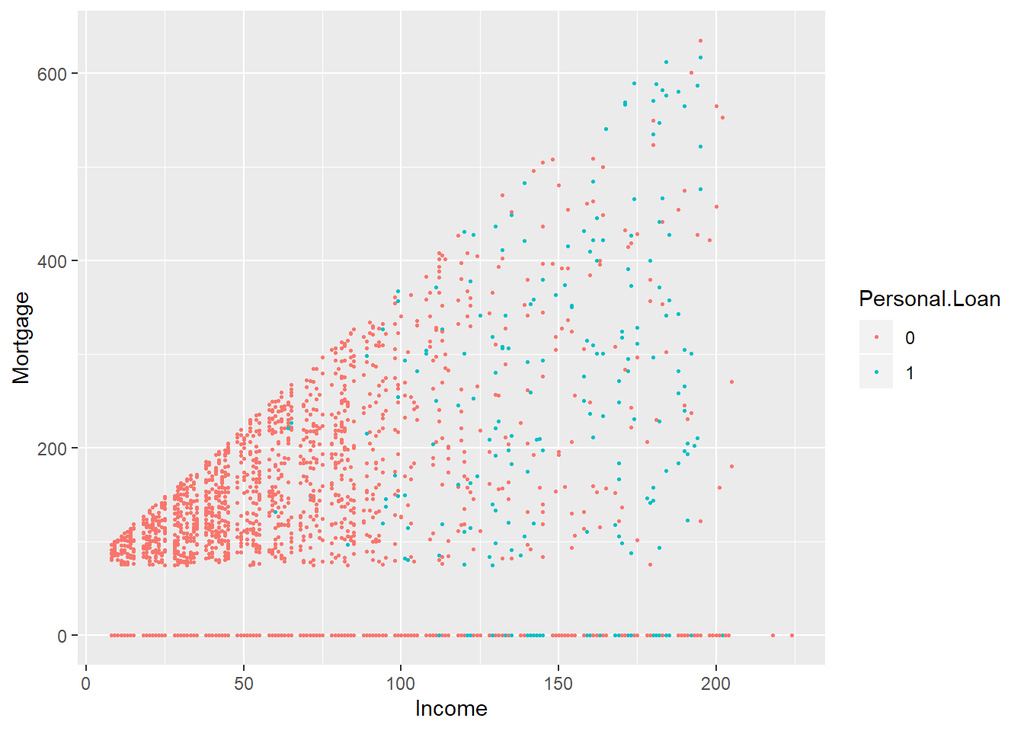

```r
# Personal loan takers are more likely to have higher educational levels

ggplot(theradata, aes(Income, y=Mortgage, color = Personal.Loan)) +
  geom_point(size = 0.5)
```

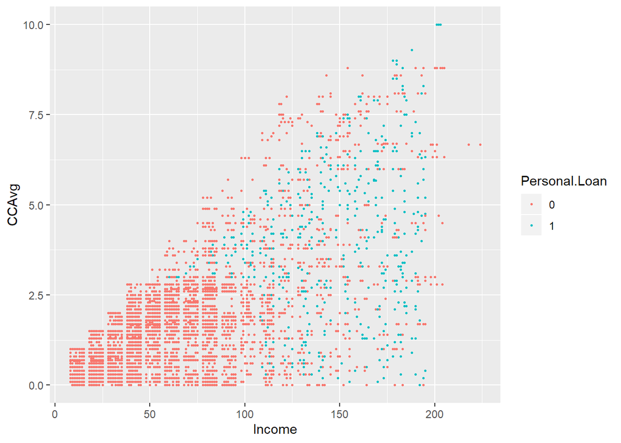

```r
# Mortgage vs Personal Loan Takeup rate by income

ggplot(theradata, aes(Income, y=CCAvg, color = Personal.Loan)) +
  geom_point(size = 0.5)
```

```r
# Credit card Spending vs Personal Loan Takeup rate by income

prop.table(table(theradata$Personal.Loan, theradata$Education)) #population
```

```
##
##          1      2      3
##   0 0.4006 0.2442 0.2592
##   1 0.0186 0.0364 0.0410
```

```r
prop.table(table(theradata$Personal.Loan, theradata$Education),1) #rows
```

```
##
##             1         2         3
##   0 0.4431416 0.2701327 0.2867257
##   1 0.1937500 0.3791667 0.4270833
```

```r
loaners <-(0.379+0.427)*100
prop.table(table(theradata$Personal.Loan, theradata$Education),2) #columns
```

```
##
##              1          2          3
##   0 0.95562977 0.87027798 0.86342438
##   1 0.04437023 0.12972202 0.13657562
```

Based on Bivariate analysis, the proportion of loan takers are a very small number (9.6%). Which could mean more potential customers for Thera Bank, depending on how they segment, educate, and attract their customers with attractive interest rates and more.

Personal Loan takers from the first batch are more likely to be graduates and above (80.6%), with higher income, more family members, and higher mortgages.This is likely to be because they are likely to be financially literate, and are financially more secure, taking on loans to manage their cashflow better.

Multivariate analysis also shows that Personal Loan acceptance is more likely from customers who have higher income, higher credit card spending with higher mortgages.

### Customer Segmentation using Clustering

To understand the segments of customers that Thera Bank has so they can better target them for better results, kmeans clustering by classification is applied to segment the large dataset we have (5000 observations). Hierarchical methods will be too computationally expensive.

Using only numerical variables, we will scale the data to have better accuracy. Euclidean distance will be applied for classification.

```r
library(cluster)

# select numerical variables
thera.clus = theradata %>% select_if(is.numeric)

# scale data for clustering
thera.scaled = scale(thera.clus, center = TRUE)
```

#### Determining optimal number of clusters

Using elbow method

```r
seed = 555
set.seed(seed)

totWss=rep(0,5)
for(k in 1:5){
  set.seed(seed)
  clust=kmeans(x=thera.scaled, centers=k, nstart=10)
  totWss[k]=clust$tot.withinss
}
print(totWss)
```

```
## [1] 29994.00 22480.19 17645.58 15368.47 13517.75
```

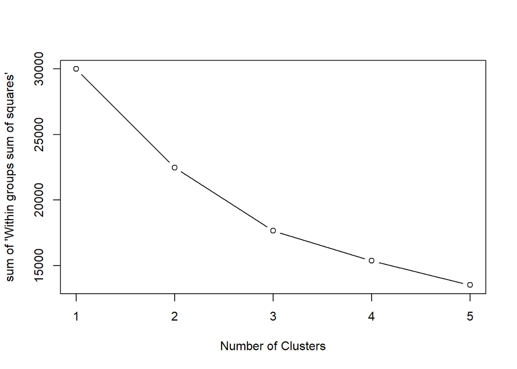

```r
plot(c(1:5), totWss, type="b", xlab="Number of Clusters",
       ylab="sum of 'Within groups sum of squares'")
```

```r
# Cross checking with secondary method
library(NbClust)

nc = NbClust(thera.scaled, min.nc = 2, max.nc = 5, method = "kmeans")
```

```r
table(nc$Best.n[1,])
```

```
##
##  0  1  2  3  5
##  2  1  5 14  4
```

Based on the two tests, a cluster size of 3 is optimal.

```r
library(factoextra)
set.seed(seed)

cluster3 = kmeans(thera.scaled, 3)
cluster3$centers
```

```
##          Age Experience     Income Family.members      CCAvg   Mortgage
## 1  0.8926064  0.8882413 -0.3392281    -0.01350373 -0.3322020 -0.1138400
## 2 -0.8876215 -0.8897696 -0.2964330     0.19159109 -0.3251408 -0.1087605
## 3 -0.1428546 -0.1265413  1.5794100    -0.42657619  1.6305552  0.5523632
```

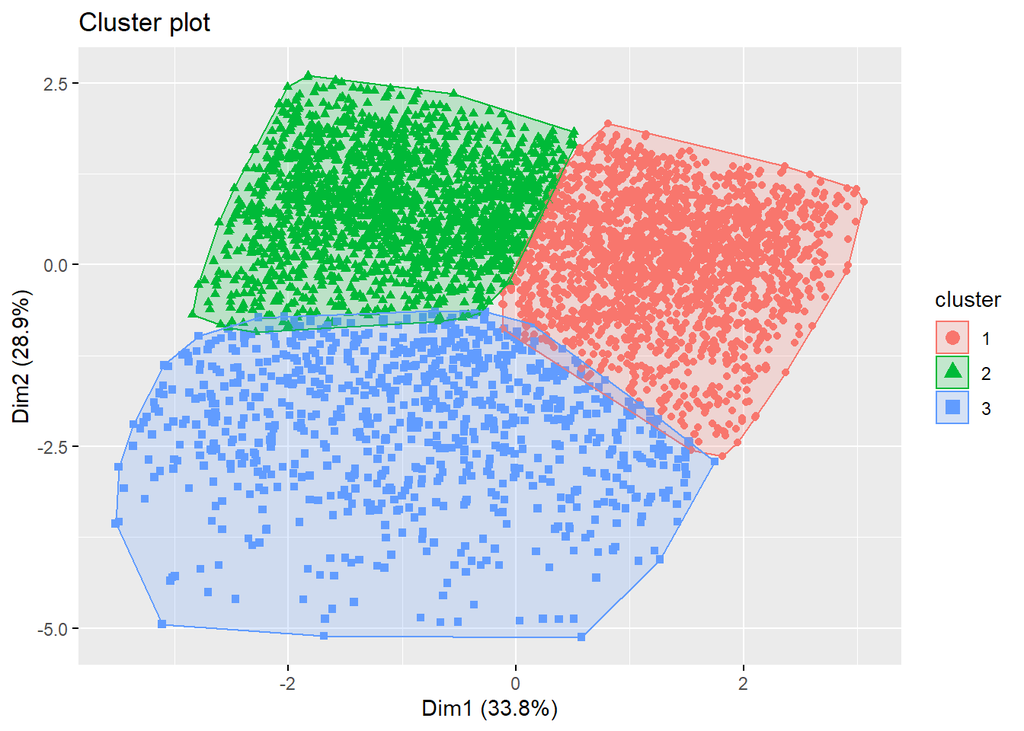

```r
fviz_cluster(cluster3, data = thera.scaled, geom = "point")
```

```r
theradata$Clusters = cluster3$cluster
prop.table(table(theradata$Clusters))
```

```
##
##      1      2      3
## 0.4284 0.4038 0.1678
```

```r
table(theradata$Clusters)
```

```
##
##    1    2    3
## 2142 2019  839
```

```r
## Aggregate numerical variables for each cluster by their means
theraProfile = aggregate(theradata[,-c(4,6,7,8,9,10,11,12,13)],list(theradata$Clusters),FUN="mean")
print(theraProfile)
```

```
##   Group.1      Age Experience    Income Family.members Clusters
## 1       1 55.57049  30.274043  58.15826       2.373016        1
## 2       2 35.16345   9.977712  60.12828       2.609708        2
## 3       3 43.70083  18.690107 146.48033       1.896305        3
```

Aggregating the data these are the 3 segments in the Population:

This group will be good to target for Personal Loans and mortgages, as they will be earning more in the future, and making more plans for family and future. New credit cards with smaller credits limits can be more appealing for them.

This group is already financially savvy, but is still good to target for not just personal loans, but also mortgage and new credit cards with higher credit limits.

This group is already financially stable, but may need to consider low interest Personal Loans for short term contingencies. Credit Card or stored valued Credit Cards with smaller credit limits may also be more appealing, in terms of security.

### Preparation of Train & Test Data

Create Train and Test Sets with a 70% Train and 30% Test split.

```r
######## 70% train, 30% test
thera.index = theradata[,-c(4,14)] # remove cluster variable & Zip

#Paritioning the data into training and test dataset
set.seed(seed)

sample = sample.split(thera.index$Personal.Loan,SplitRatio = 0.7)
p_train = subset(thera.index,sample == TRUE)
p_test = subset(thera.index,sample == FALSE)
nrow(p_train)
```

```
## [1] 3500
```

```r
nrow(p_test)
```

```
## [1] 1500
```

```r
head(p_train)
```

```
## # A tibble: 6 x 12
##     Age Experience Income Family.members CCAvg Education Mortgage Personal.Loan
##   <dbl>      <dbl>  <dbl>          <dbl> <dbl> <fct>        <dbl> <fct>
## 1    25          1     49              4   1.6 1                0 0
## 2    35          9    100              1   2.7 2                0 0
## 3    35          8     45              4   1   2                0 0
## 4    37         13     29              4   0.4 2              155 0
## 5    50         24     22              1   0.3 3                0 0
## 6    35         10     81              3   0.6 2              104 0
## # ... with 4 more variables: Securities.Account <fct>, CD.Account <fct>,
## #   Online <fct>, CreditCard <fct>
```

```r
## proportion of class
prop.table(table(thera.index$Personal.Loan)) # original proportion
```

```
##
##     0     1
## 0.904 0.096
```

```r
# Checking the Personal Loan distribution
prop.table(table(p_train$Personal.Loan)) # train set to match original proportion
```

```
##
##     0     1
## 0.904 0.096
```

```r
table(p_train$Personal.Loan)
```

```
##
##    0    1
## 3164  336
```

### Build CART Model

Classification and Regression trees is a powerful yet simple decision tree algorithm used to learn and grow data. “rpart” and “rpart.plot” libraries are used to build decision treees. A complex tree is first build, by setting the “cost complexity” threshold to “0” with a minimum bucket size of 5.

```r
#Setting the control parameters
r.ctrl = rpart.control(minsplit = 10, minbucket = 5, cp = 0, xval = 10)


#Building the CART model
dt_model <- rpart(formula = Personal.Loan~ ., data = p_train, method = "class", control = r.ctrl)
dt_model
```

```
## n= 3500
##
## node), split, n, loss, yval, (yprob)
##       * denotes terminal node
##
##   1) root 3500 336 0 (0.904000000 0.096000000)
##     2) Income< 114.5 2803  59 0 (0.978951124 0.021048876)
##       4) CCAvg< 2.95 2601  11 0 (0.995770857 0.004229143)
##         8) Income< 106.5 2510   0 0 (1.000000000 0.000000000) *
##         9) Income>=106.5 91  11 0 (0.879120879 0.120879121)
##          18) Family.members< 3.5 70   5 0 (0.928571429 0.071428571) *
##          19) Family.members>=3.5 21   6 0 (0.714285714 0.285714286)
##            38) Education=3 16   2 0 (0.875000000 0.125000000) *
##            39) Education=1,2 5   1 1 (0.200000000 0.800000000) *
##       5) CCAvg>=2.95 202  48 0 (0.762376238 0.237623762)
##        10) CD.Account=0 188  36 0 (0.808510638 0.191489362)
##          20) Income< 92.5 118  11 0 (0.906779661 0.093220339)
##            40) CCAvg>=3.15 94   5 0 (0.946808511 0.053191489)
##              80) Education=1,3 79   1 0 (0.987341772 0.012658228) *
##              81) Education=2 15   4 0 (0.733333333 0.266666667)
##               162) Family.members>=3.5 8   0 0 (1.000000000 0.000000000) *
##               163) Family.members< 3.5 7   3 1 (0.428571429 0.571428571) *
##            41) CCAvg< 3.15 24   6 0 (0.750000000 0.250000000)
##              82) Mortgage< 66 19   3 0 (0.842105263 0.157894737) *
##              83) Mortgage>=66 5   2 1 (0.400000000 0.600000000) *
##          21) Income>=92.5 70  25 0 (0.642857143 0.357142857)
##            42) Family.members< 2.5 49   9 0 (0.816326531 0.183673469)
##              84) Education=1 33   2 0 (0.939393939 0.060606061) *
##              85) Education=2,3 16   7 0 (0.562500000 0.437500000)
##               170) Family.members>=1.5 10   3 0 (0.700000000 0.300000000) *
##               171) Family.members< 1.5 6   2 1 (0.333333333 0.666666667) *
##            43) Family.members>=2.5 21   5 1 (0.238095238 0.761904762)
##              86) Age>=56 7   2 0 (0.714285714 0.285714286) *
##              87) Age< 56 14   0 1 (0.000000000 1.000000000) *
##        11) CD.Account=1 14   2 1 (0.142857143 0.857142857) *
##     3) Income>=114.5 697 277 0 (0.602582496 0.397417504)
##       6) Education=1 463  49 0 (0.894168467 0.105831533)
##        12) Family.members< 2.5 414   0 0 (1.000000000 0.000000000) *
##        13) Family.members>=2.5 49   0 1 (0.000000000 1.000000000) *
##       7) Education=2,3 234   6 1 (0.025641026 0.974358974)
##        14) Income< 116.5 14   6 1 (0.428571429 0.571428571)
##          28) CCAvg< 2.8 8   3 0 (0.625000000 0.375000000) *
##          29) CCAvg>=2.8 6   1 1 (0.166666667 0.833333333) *
##        15) Income>=116.5 220   0 1 (0.000000000 1.000000000) *
```

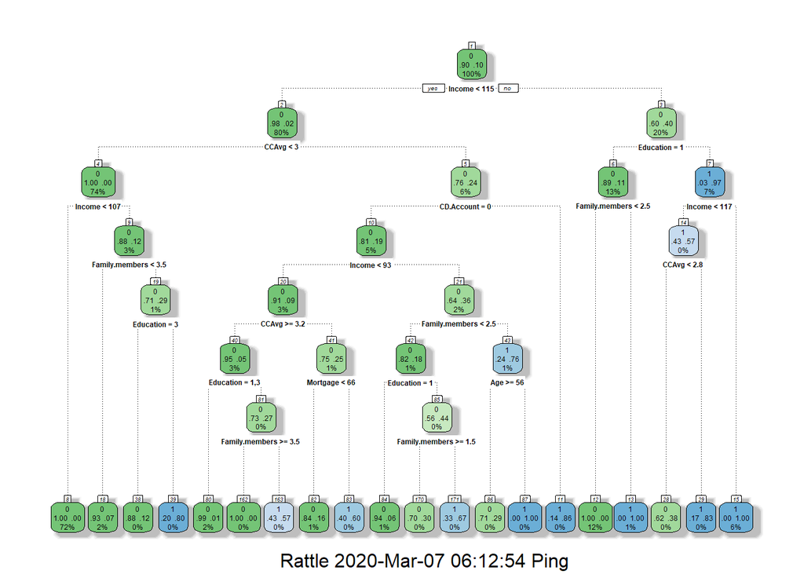

```r
#Displaying the decision tree
fancyRpartPlot(dt_model)
```

```r
# The cost complexity table can be obtained using the printcp or plotcp functions
printcp(dt_model)
```

```
##
## Classification tree:
## rpart(formula = Personal.Loan ~ ., data = p_train, method = "class",
##     control = r.ctrl)
##
## Variables actually used in tree construction:
## [1] Age            CCAvg          CD.Account     Education      Family.members
## [6] Income         Mortgage
##
## Root node error: 336/3500 = 0.096
##
## n= 3500
##
##          CP nsplit rel error  xerror     xstd
## 1 0.3303571      0  1.000000 1.00000 0.051870
## 2 0.1458333      2  0.339286 0.33929 0.031255
## 3 0.0148810      3  0.193452 0.19345 0.023771
## 4 0.0089286      7  0.130952 0.15774 0.021502
## 5 0.0029762      8  0.122024 0.16964 0.022286
## 6 0.0014881     15  0.101190 0.18155 0.023041
## 7 0.0000000     19  0.095238 0.18155 0.023041
```

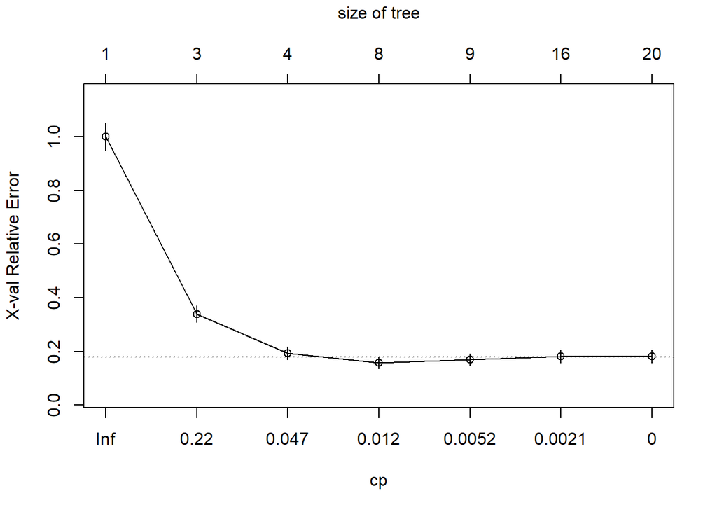

```r
plotcp(dt_model)
```

The first complex tree above can be pruned using a cost complexity threshold of 0.0052 to give a simpler tree.

```r
# Pruning the tree
dt_modelprune = prune(dt_model, cp= 0.0052,"CP")
printcp(dt_modelprune)
```

```
##
## Classification tree:
## rpart(formula = Personal.Loan ~ ., data = p_train, method = "class",
##     control = r.ctrl)
##
## Variables actually used in tree construction:
## [1] Age            CCAvg          CD.Account     Education      Family.members
## [6] Income
##
## Root node error: 336/3500 = 0.096
##
## n= 3500
##
##          CP nsplit rel error  xerror     xstd
## 1 0.3303571      0   1.00000 1.00000 0.051870
## 2 0.1458333      2   0.33929 0.33929 0.031255
## 3 0.0148810      3   0.19345 0.19345 0.023771
## 4 0.0089286      7   0.13095 0.15774 0.021502
## 5 0.0052000      8   0.12202 0.16964 0.022286
```

[figure not shown]

```r
fancyRpartPlot(dt_modelprune)
```

```r
dt_modelprune
```

```
## n= 3500
##
## node), split, n, loss, yval, (yprob)
##       * denotes terminal node
##
##  1) root 3500 336 0 (0.904000000 0.096000000)
##    2) Income< 114.5 2803  59 0 (0.978951124 0.021048876)
##      4) CCAvg< 2.95 2601  11 0 (0.995770857 0.004229143) *
##      5) CCAvg>=2.95 202  48 0 (0.762376238 0.237623762)
##       10) CD.Account=0 188  36 0 (0.808510638 0.191489362)
##         20) Income< 92.5 118  11 0 (0.906779661 0.093220339) *
##         21) Income>=92.5 70  25 0 (0.642857143 0.357142857)
##           42) Family.members< 2.5 49   9 0 (0.816326531 0.183673469) *
##           43) Family.members>=2.5 21   5 1 (0.238095238 0.761904762)
##             86) Age>=56 7   2 0 (0.714285714 0.285714286) *
##             87) Age< 56 14   0 1 (0.000000000 1.000000000) *
##       11) CD.Account=1 14   2 1 (0.142857143 0.857142857) *
##    3) Income>=114.5 697 277 0 (0.602582496 0.397417504)
##      6) Education=1 463  49 0 (0.894168467 0.105831533)
##       12) Family.members< 2.5 414   0 0 (1.000000000 0.000000000) *
##       13) Family.members>=2.5 49   0 1 (0.000000000 1.000000000) *
##      7) Education=2,3 234   6 1 (0.025641026 0.974358974) *
```

```r
dt_modelprune$variable.importance
```

```
##          Education             Income     Family.members              CCAvg
##        236.3822536        168.9508088        157.2672747         91.5251657
##         CD.Account           Mortgage                Age         Experience
##         43.6165094         18.9595698          6.0478463          5.8729675
## Securities.Account
##          0.6802721
```

Based on the results of the Pruned CART decision tree, the most important variables that influence the prediction of Personal Loans uptake are:

Education, Income, Family.members, CCAvg, CD.Account

The first split occurs when Income is less than or greater than $115K. If lesser, Credit Card average spending and CD Accounts will affect the prediction. If more, Education and Family Member count will affect the prediction outcome on Personal Loan.

### Random Forest

An ensemble learning method which outputs multiple decision trees and uses bagging and randomness of varying degrees to give an aggregated output giving a more robust prediction.

```r
# 70% train, 30% test
p_trainrf <- p_train
p_testrf <- p_test
```

Similar to CART, we split train and test data at a 70% and 30% split. The first randomforest is created to determine variables that influence Personal.Loan status to be taken up.

```r
#mtry
sqrt(12)
```

```
## [1] 3.464102
```

```r
#nodesize
0.1 * 3500
```

```
## [1] 350
```

```r
##Build the first RF model

set.seed(seed)

rf_first = randomForest(Personal.Loan ~ .,
                        data = p_trainrf,
                        ntree=501,
                        mtry = 3,
                        nodesize = 350,
                        importance=TRUE)

# error rate
error = rf_first$err.rate
head(error)
```

```
##             OOB            0         1
## [1,] 0.05909798 0.0017006803 0.6727273
## [2,] 0.08408551 0.0005254861 0.8712871
## [3,] 0.08012094 0.0075187970 0.7698413
## [4,] 0.08128162 0.0063456514 0.7832168
## [5,] 0.08296390 0.0035014006 0.8344371
## [6,] 0.08259677 0.0080889788 0.7866242
```

```r
#out of bag error
oob_err = error[nrow(error), "OOB"]
print(oob_err)
```

```
##        OOB
## 0.07342857
```

```r
print(rf_first)#Print the model to see the OOB and error rate
```

```
##
## Call:
##  randomForest(formula = Personal.Loan ~ ., data = p_trainrf, ntree = 501,      mtry = 3, nodesize = 350, importance = TRUE)
##                Type of random forest: classification
##                      Number of trees: 501
## No. of variables tried at each split: 3
##
##         OOB estimate of  error rate: 7.34%
## Confusion matrix:
##      0  1  class.error
## 0 3163  1 0.0003160556
## 1  256 80 0.7619047619
```

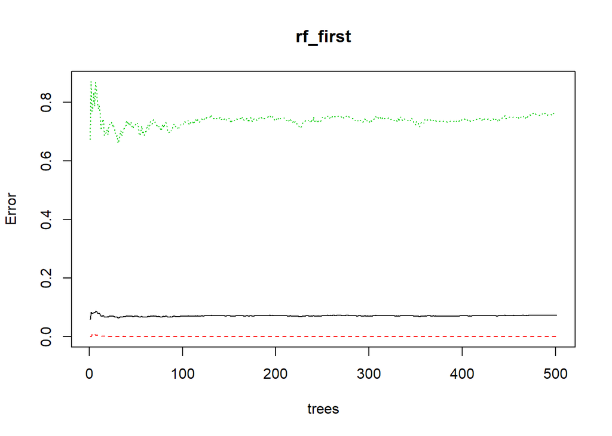

```r
plot(rf_first) #Plot rf_first to estimate ntree count and OOB error
```

```r
randomForest::importance(rf_first)
```

```
##                             0          1 MeanDecreaseAccuracy MeanDecreaseGini
## Age                 3.1734956 -1.5307697            3.0319244       0.70587738
## Experience          2.1855330 -0.9160152            2.0099678       0.65101680
## Income             22.6438949 19.8426667           22.8287779     116.69470921
## Family.members     12.0888508  9.9009586           12.0356809      15.90114269
## CCAvg              14.9024753 11.5636211           14.7443388      63.34737795
## Education          18.9160945 17.6762617           18.9101707      39.87827934
## Mortgage            5.8369939 -2.0626519            3.7361085       9.91962127
## Securities.Account  0.9320973  0.1939296            0.8902354       0.08793320
## CD.Account          6.0500858  2.2791366            4.3415381      18.50374333
## Online              1.5009563  0.8884116            1.8183958       0.07137357
## CreditCard          1.9505957  2.4397754            2.7946089       0.25756991
```

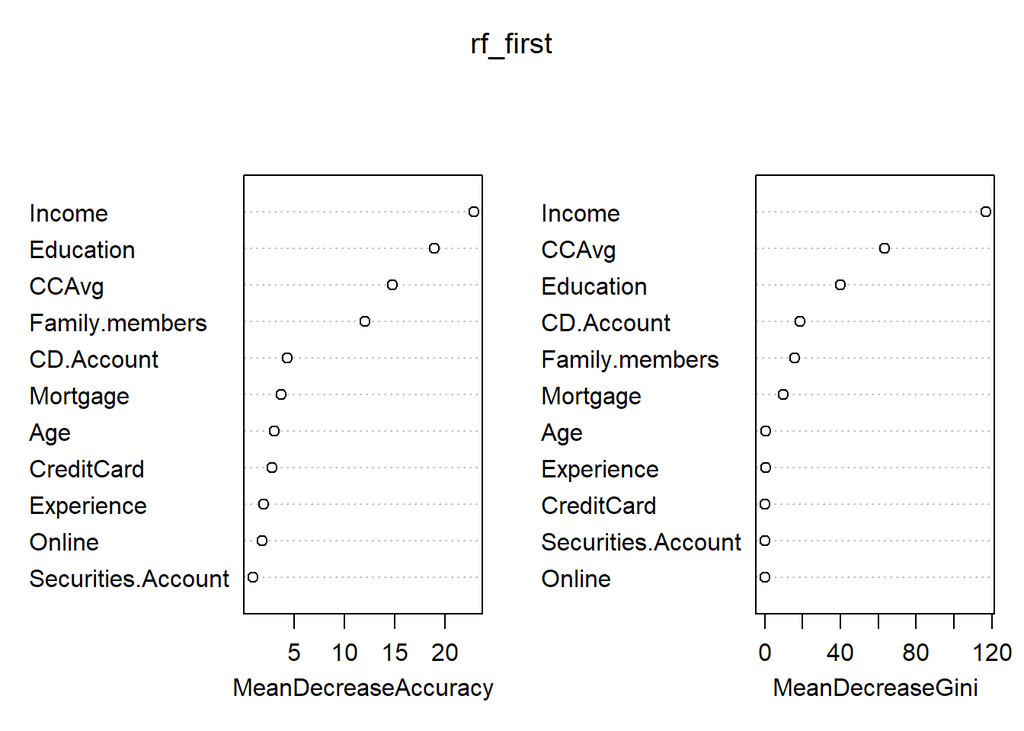

```r
varImpPlot(rf_first) #identify variable importance
```

The error rate plot reveals that anything more than 230 trees is really not that valuable. Initial OOB error was 7.34%

```
## mtry = 3  OOB error = 6.14%
## Searching left ...
## mtry = 2     OOB error = 8.14%
## -0.3255814 0.05
## Searching right ...
## mtry = 6     OOB error = 3.26%
## 0.4697674 0.05
## mtry = 11    OOB error = 3.26%
## 0 0.05
```

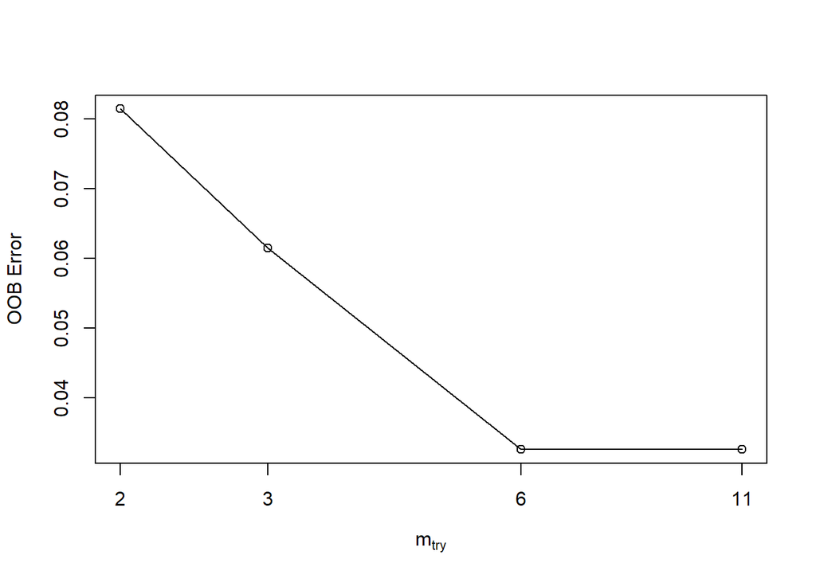

```r
set.seed(seed)

tune_rf = tuneRF(x = subset(p_trainrf, select = -Personal.Loan),
                y = p_trainrf$Personal.Loan,
                mtryStart = 3,
                nodesize= 305,
                ntree = 230,
                doBest = TRUE,
                trace = TRUE,
                plot=TRUE,
                importance=TRUE)
```

```r
Rforest = randomForest(Personal.Loan~.,
                    data=p_trainrf,
                    ntree=230,
                    mtry=6,
                    nodesize=10,
                    importance=TRUE)
print(Rforest)
```

```
##
## Call:
##  randomForest(formula = Personal.Loan ~ ., data = p_trainrf, ntree = 230,      mtry = 6, nodesize = 10, importance = TRUE)
##                Type of random forest: classification
##                      Number of trees: 230
## No. of variables tried at each split: 6
##
##         OOB estimate of  error rate: 1.26%
## Confusion matrix:
##      0   1 class.error
## 0 3156   8 0.002528445
## 1   36 300 0.107142857
```

```r
randomForest::importance(Rforest)
```

```
##                               0           1 MeanDecreaseAccuracy
## Age                 10.91180185 -1.30372678           10.4462776
## Experience          11.84430829  1.29520312           11.7956601
## Income             126.93699847 70.51662705          138.0549757
## Family.members      92.66808537 41.13453837           93.5508412
## CCAvg               23.66973856 24.51682327           26.2917374
## Education          156.42518602 65.68151937          166.0448687
## Mortgage             5.09776837 -2.04047699            4.5454629
## Securities.Account   0.01822131  2.24456641            1.6092510
## CD.Account           9.94698969  7.71518035           12.1631253
## Online               0.87707482  0.08038858            0.9870859
## CreditCard           2.16237994 -0.36847848            1.6202217
##                    MeanDecreaseGini
## Age                      10.0384609
## Experience                8.7371618
## Income                  179.1126288
## Family.members           91.4896443
## CCAvg                    64.7793613
## Education               189.8151486
## Mortgage                  5.9003540
## Securities.Account        0.3883894
## CD.Account               17.2394171
## Online                    0.9371085
## CreditCard                0.7495176
```

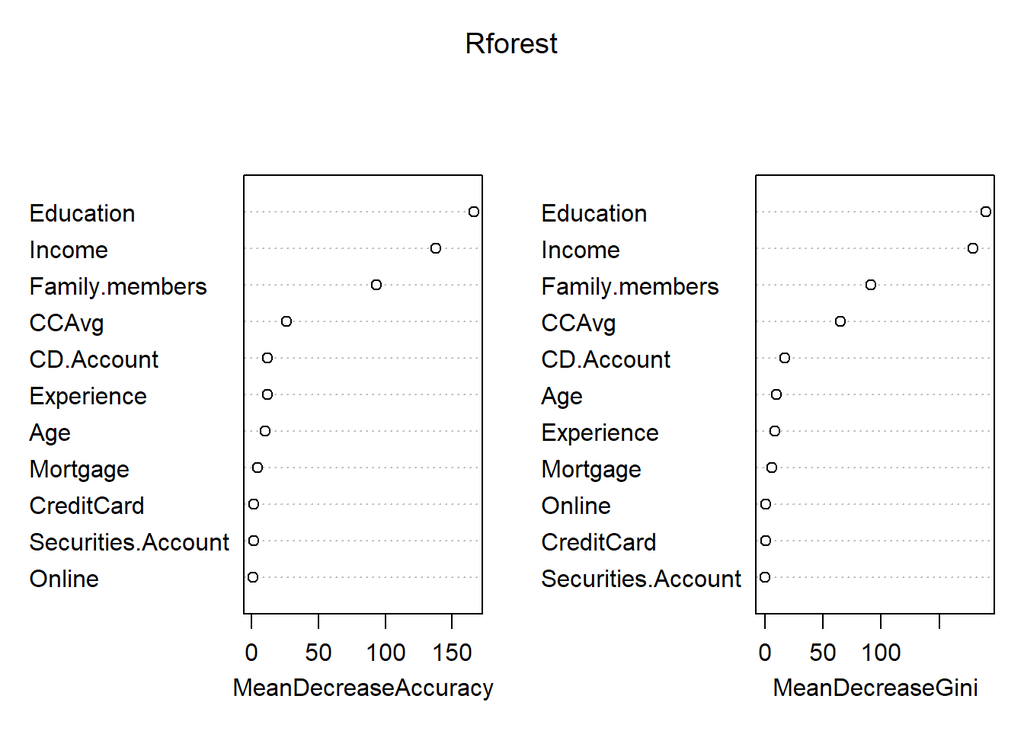

```r
varImpPlot(Rforest) #identify variable importance
```

The larger the MeanDecrease values, the more important the variable. For the first random forest generated, the key variables are Income, Education, CCAvg, and Family Members. After pruning, the tuned random forest showed that Education was the most important variable as predictors for acceptance of Personal loans followed by Income, Family and CC Avg.

The OOB value also reduced to 1.26%, from 7.34% improving on accuracy.

### CART Model Performance Measures

For a model with a class output, the confusion matrix provides the count of correct and wrong predictions.

```r
# Cart Train Set- adding prediction and prob score variables
p_train$predict.class <- predict(dt_modelprune, p_train, type = "class")
p_train$predict.score <- predict(dt_modelprune, p_train, type = "prob")
head(p_train)
```

```
## # A tibble: 6 x 14
##     Age Experience Income Family.members CCAvg Education Mortgage Personal.Loan
##   <dbl>      <dbl>  <dbl>          <dbl> <dbl> <fct>        <dbl> <fct>
## 1    25          1     49              4   1.6 1                0 0
## 2    35          9    100              1   2.7 2                0 0
## 3    35          8     45              4   1   2                0 0
## 4    37         13     29              4   0.4 2              155 0
## 5    50         24     22              1   0.3 3                0 0
## 6    35         10     81              3   0.6 2              104 0
## # ... with 7 more variables: Securities.Account <fct>, CD.Account <fct>,
## #   Online <fct>, CreditCard <fct>, predict.class <fct>,
## #   predict.score[,"0"] <dbl>, [,"1"] <dbl>
```

```r
# Cart Test Set- adding prediction and prob score variables
p_test$predict.class <- predict(dt_modelprune, p_test, type = "class")
p_test$predict.score <- predict(dt_modelprune, p_test, type = "prob")
head(p_test)
```

```
## # A tibble: 6 x 14
##     Age Experience Income Family.members CCAvg Education Mortgage Personal.Loan
##   <dbl>      <dbl>  <dbl>          <dbl> <dbl> <fct>        <dbl> <fct>
## 1    45         19     34              3   1.5 1                0 0
## 2    39         15     11              1   1   1                0 0
## 3    53         27     72              2   1.5 2                0 0
## 4    65         39    105              4   2.4 3                0 0
## 5    29          5     45              3   0.1 2                0 0
## 6    60         30     22              1   1.5 3                0 0
## # ... with 7 more variables: Securities.Account <fct>, CD.Account <fct>,
## #   Online <fct>, CreditCard <fct>, predict.class <fct>,
## #   predict.score[,"0"] <dbl>, [,"1"] <dbl>
```

For a model with a class output, the confusion matrix provides the count of correct and wrong predictions.

```r
# Cart - Interpretation of Confusion Matrix - Train
confusionMatrix(p_train$Personal.Loan, p_train$predict.class, positive = "1")
```

```
## Confusion Matrix and Statistics
##
##           Reference
## Prediction    0    1
##          0 3156    8
##          1   33  303
##
##                Accuracy : 0.9883
##                  95% CI : (0.9841, 0.9916)
##     No Information Rate : 0.9111
##     P-Value [Acc > NIR] : < 2.2e-16
##
##                   Kappa : 0.9302
##
##  Mcnemar's Test P-Value : 0.0001781
##
##             Sensitivity : 0.97428
##             Specificity : 0.98965
##          Pos Pred Value : 0.90179
##          Neg Pred Value : 0.99747
##              Prevalence : 0.08886
##          Detection Rate : 0.08657
##    Detection Prevalence : 0.09600
##       Balanced Accuracy : 0.98196
##
##        'Positive' Class : 1
##
```

```r
# Cart - Interpretation of Confusion Matrix - Test
confusionMatrix(p_test$Personal.Loan, p_test$predict.class, positive = "1")
```

```
## Confusion Matrix and Statistics
##
##           Reference
## Prediction    0    1
##          0 1351    5
##          1   20  124
##
##                Accuracy : 0.9833
##                  95% CI : (0.9755, 0.9892)
##     No Information Rate : 0.914
##     P-Value [Acc > NIR] : < 2e-16
##
##                   Kappa : 0.8993
##
##  Mcnemar's Test P-Value : 0.00511
##
##             Sensitivity : 0.96124
##             Specificity : 0.98541
##          Pos Pred Value : 0.86111
##          Neg Pred Value : 0.99631
##              Prevalence : 0.08600
##          Detection Rate : 0.08267
##    Detection Prevalence : 0.09600
##       Balanced Accuracy : 0.97333
##
##        'Positive' Class : 1
##
```

In the train set, the accuracy rate of correct predictions is 98.83%, and the test set has an accuracy of 98.33% (1475/1500). Classification error rate of train set is 1.17%, and with test set is 1.67%.

The performance of this CART model has a high credibility based on high sensitivity and specificity rates for the train set. It identifies the variables in the train and test set, as the accuracy result are both similarly high.

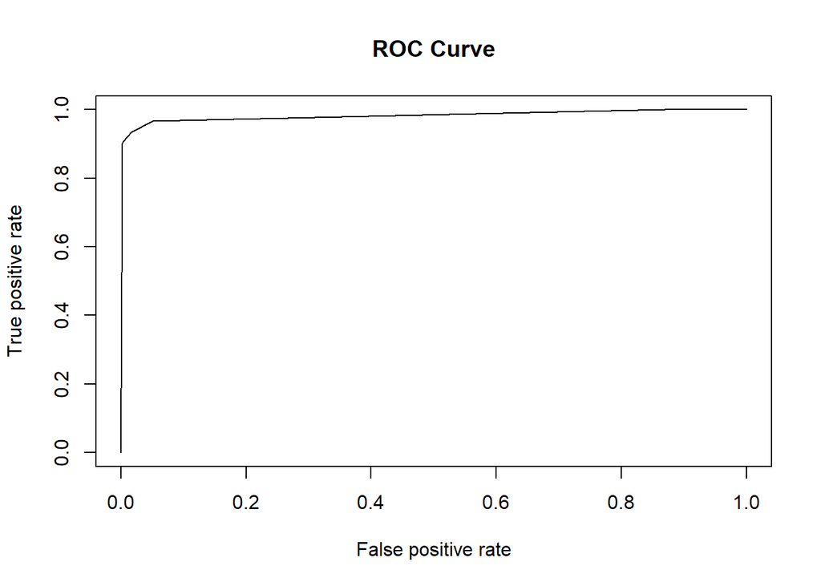

```r
# Cart - Performance Metrics ROC AUC - Train
predCART <- prediction(p_train$predict.score[,2], p_train$Personal.Loan)
perfCART <- performance(predCART, "tpr", "fpr")
plot(perfCART, main = "ROC Curve")
```

```r
auc <- performance(predCART, "auc");
auc <- as.numeric(auc@y.values)
auc
```

```
## [1] 0.9828215
```

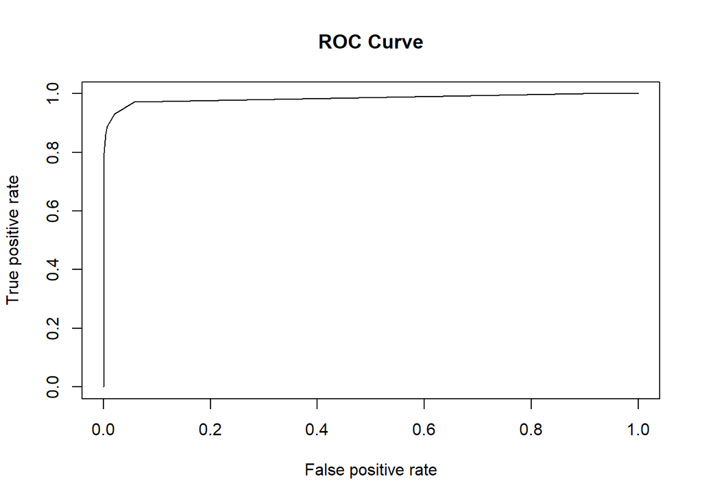

```r
# Cart - Performance Metrics ROC AUC - Test
TpredCART <- prediction(p_test$predict.score[,2], p_test$Personal.Loan)
TperfCART <- performance(TpredCART, "tpr", "fpr")
plot(TperfCART, main = "ROC Curve")
```

```r
aucTest <- performance(TpredCART, "auc");
aucTest <- as.numeric(aucTest@y.values)
aucTest
```

```
## [1] 0.9837323
```

CART - ROC curve

```r
# Cart - Performance Metrics KS - train & test
cartks <- max(perfCART@y.values[[1]]-perfCART@x.values[[1]])
cartkstest <-max(TperfCART@y.values[[1]]-TperfCART@x.values[[1]])
cartks
```

```
## [1] 0.9177729
```

```r
cartkstest
```

```
## [1] 0.9147001
```

```r
# Cart - Performance Metrics Gini - train & test
library(ineq)
cartgini.train = ineq(p_train$predict.score[,2], type="Gini")
cartgini.test = ineq(p_test$predict.score[,2], type="Gini")
```

The K-S is used for classification with probability outputs as well, it is a measure of the degree of separation between positive and negative distributions The higher the value, the better the model. For the CART train set - 0.9177, and test set - 0.9147

### Random Forest Model Performance Measures

```r
# RF Train & Test Set- adding prediction and prob score variables

p_trainrf$predict.class = predict(Rforest,data=p_trainrf,type="class")
p_trainrf$predict.score = predict(Rforest,data=p_trainrf,type="prob")[,"1"]
head(p_trainrf)
```

```
## # A tibble: 6 x 14
##     Age Experience Income Family.members CCAvg Education Mortgage Personal.Loan
##   <dbl>      <dbl>  <dbl>          <dbl> <dbl> <fct>        <dbl> <fct>
## 1    25          1     49              4   1.6 1                0 0
## 2    35          9    100              1   2.7 2                0 0
## 3    35          8     45              4   1   2                0 0
## 4    37         13     29              4   0.4 2              155 0
## 5    50         24     22              1   0.3 3                0 0
## 6    35         10     81              3   0.6 2              104 0
## # ... with 6 more variables: Securities.Account <fct>, CD.Account <fct>,
## #   Online <fct>, CreditCard <fct>, predict.class <fct>, predict.score <dbl>
```

```r
p_testrf$predict.class = predict(Rforest,p_testrf,type="class")
p_testrf$predict.score = predict(Rforest,p_testrf,type="prob")[,"1"]
head(p_testrf)
```

```
## # A tibble: 6 x 14
##     Age Experience Income Family.members CCAvg Education Mortgage Personal.Loan
##   <dbl>      <dbl>  <dbl>          <dbl> <dbl> <fct>        <dbl> <fct>
## 1    45         19     34              3   1.5 1                0 0
## 2    39         15     11              1   1   1                0 0
## 3    53         27     72              2   1.5 2                0 0
## 4    65         39    105              4   2.4 3                0 0
## 5    29          5     45              3   0.1 2                0 0
## 6    60         30     22              1   1.5 3                0 0
## # ... with 6 more variables: Securities.Account <fct>, CD.Account <fct>,
## #   Online <fct>, CreditCard <fct>, predict.class <fct>, predict.score <dbl>
```

```r
# RF Interpretation of Confusion Matrix - Train
confusionMatrix(p_trainrf$Personal.Loan, p_trainrf$predict.class, positive = "1")
```

```
## Confusion Matrix and Statistics
##
##           Reference
## Prediction    0    1
##          0 3156    8
##          1   36  300
##
##                Accuracy : 0.9874
##                  95% CI : (0.9832, 0.9909)
##     No Information Rate : 0.912
##     P-Value [Acc > NIR] : < 2.2e-16
##
##                   Kappa : 0.9248
##
##  Mcnemar's Test P-Value : 4.693e-05
##
##             Sensitivity : 0.97403
##             Specificity : 0.98872
##          Pos Pred Value : 0.89286
##          Neg Pred Value : 0.99747
##              Prevalence : 0.08800
##          Detection Rate : 0.08571
##    Detection Prevalence : 0.09600
##       Balanced Accuracy : 0.98137
##
##        'Positive' Class : 1
##
```

```r
# RF Interpretation of Confusion Matrix - Test
confusionMatrix(p_testrf$Personal.Loan, p_testrf$predict.class, positive = "1")
```

```
## Confusion Matrix and Statistics
##
##           Reference
## Prediction    0    1
##          0 1349    7
##          1   12  132
##
##                Accuracy : 0.9873
##                  95% CI : (0.9803, 0.9924)
##     No Information Rate : 0.9073
##     P-Value [Acc > NIR] : <2e-16
##
##                   Kappa : 0.9259
##
##  Mcnemar's Test P-Value : 0.3588
##
##             Sensitivity : 0.94964
##             Specificity : 0.99118
##          Pos Pred Value : 0.91667
##          Neg Pred Value : 0.99484
##              Prevalence : 0.09267
##          Detection Rate : 0.08800
##    Detection Prevalence : 0.09600
##       Balanced Accuracy : 0.97041
##
##        'Positive' Class : 1
##
```

In the train set, the accuracy rate of correct predictions is 98.74%, and the test set has an accuracy of 98.73% (1481/1500). Classification error rate of train set is 1.26%, and with test set is 1.27%.

The sensitivity (true positive rate) of the train set is 97.40%, and the test set at 94.96% The specificity (true negative rate) of the train set is 98.87% and the test set is improved at 99.12%.

The proportion of actual negatives that are correctly identified are higher than actual positives for test set.Based on the test model, the bank is more likely to target customers who are likely to accept the Personal Loan offers.

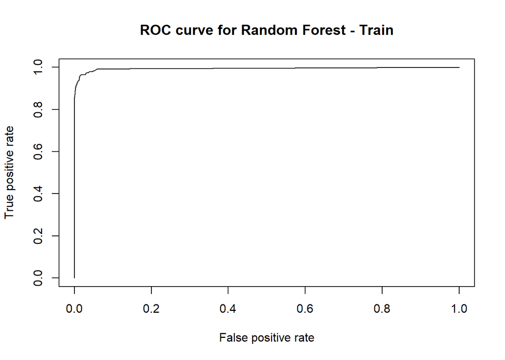

```r
# RF Performance Metrics ROC - Train
predrf.train <- prediction(p_trainrf$predict.score, p_trainrf$Personal.Loan)
perfrf.train <- performance(predrf.train, "tpr", "fpr")
plot(perfrf.train, main = "ROC curve for Random Forest - Train")
```

```r
aucrf.train <- performance(predrf.train,"auc");
aucrf.train <- as.numeric(aucrf.train@y.values)
aucrf.train
```

```
## [1] 0.9943627
```

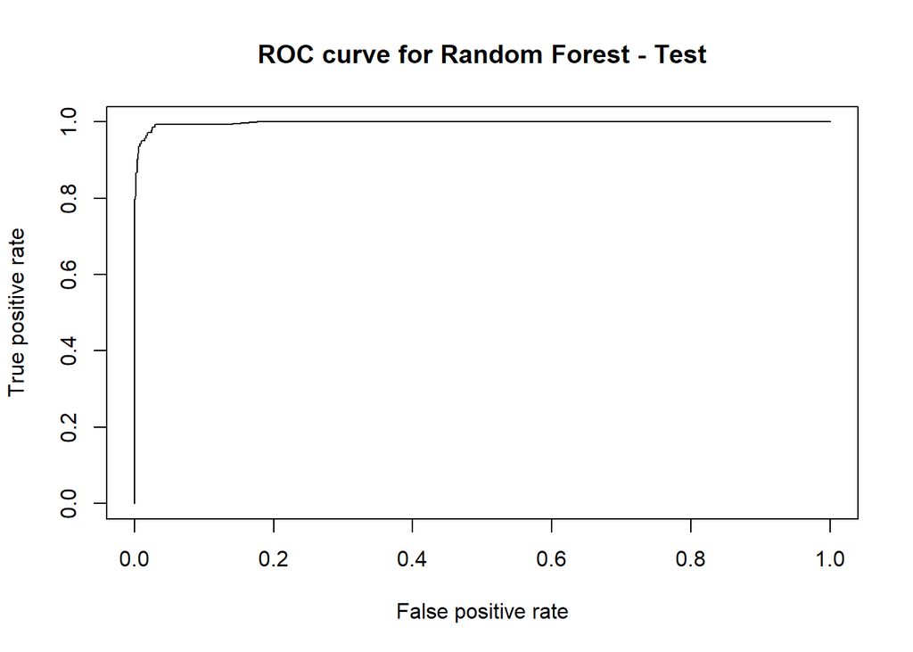

```r
# RF Performance Metrics ROC - Test
predrf.test <- prediction(p_testrf$predict.score, p_testrf$Personal.Loan)
perfrf.test <- performance(predrf.test, "tpr", "fpr")
plot(perfrf.test, main = "ROC curve for Random Forest - Test")
```

```r
aucrf.test <- performance(predrf.test,"auc");
aucrf.test <- as.numeric(aucrf.test@y.values)
aucrf.test
```

```
## [1] 0.9974368
```

Random Forest - ROC curve

The Area Under the ROC curve performance test us a measure of how good the model is. This uses the probability outputs to map a curve. The performance for the Random train set is - 0.9943, and for the test set is - 0.9974, the closer it is to 1.0, the better the fit/model performance. Thus, the Random Forest fared better than CART model.

```r
# RF Performance Metrics KS Test - Train
KS_rftrain <- max(attr(perfrf.test, 'y.values')[[1]]-attr(perfrf.test, 'x.values')[[1]])
KS_rftrain
```

```
## [1] 0.963557
```

```r
# RF Performance Metrics KS Test - Test
KS_rftest <- max(attr(perfrf.test, 'y.values')[[1]]-attr(perfrf.test, 'x.values')[[1]])
KS_rftest
```

```
## [1] 0.963557
```

```r
# RF Gini Test
rfgini.train = ineq(p_trainrf$predict.score, type="Gini")
rfgini.test = ineq(p_testrf$predict.score, type="Gini")
rfgini.train
```

```
## [1] 0.8988784
```

```r
rfgini.test
```

```
## [1] 0.8991367
```

The Gini Coefficient ia a ratio derived from ROC curve and a formula of Gini = 2*AUC -1 Above 60% is a good model, for the Random Forest train model - 89.88%, and test model - 89.91% Inferences

### Model Validation and Insights

Thera Bank’s main purpose for this consult is to build the best model which will classify the right target customers who have a higher probability of getting a Personal Loan with the bank and to convert more liability customers to asset customers so as to earn more via interest on loan repayments.

The best model will be a model that is able to improve the yield in getting a Personal Loan, increasing their conversion metrics of more than 9.6%, with a highly targeted group of customers so as to reduce EDM/Advertising costs.

Based on our Model Testing and Refinements using CART and Random Forest, Random Forest model will be a better fit for Thera Bank’s needs. Apart from the higher accuracy score (98.73%), it also has higher specificity (99.12%) than the CART model - This metric shows that the proportion of actual negatives that are correctly identified are higher than actual positives for test set. Based on the test model, the bank is more likely to target customers using the variables of Education, Income, Family Members and Credit Card Spending who are likely to accept the Personal Loan offers. Additionally, the ROC score is also higher for random forest model as compared to the CART model at 0.9974 for the test set.